# week 5

## Homework

· Calculate means, SDs, and confidence intervals (89%, 95%, 99%) for one continuous and one binary variable. Interpret the confidence intervals.

· Do two simulations (one continuous, one binary) to show that simulation-based standard deviations of the estimate converge to the formula-based standard error of the sampling distribution. Explain the result to show you understand what you did.

## Continuous Variable

The continuous variable I choose is the life Expectancy from dataset Gapminder.

Mean of LifeExp = 59.47

Standard Deviation of lifeExp = 12.92

Standard Error = $\frac{SD}{\sqrt{n}}$ = 0.3129845

## Confidence Interval

89% confidence interval = (58.97 , 59.97)

For the population life expectancy, the probability that the expectancy is within range 58.97 to 59.97 years is 0.89.

95% confidence interval = (58.86 , 60.09)

For the population life expectancy, the probability that the expectancy is within range 58.86 to 60.09 years is 0.95.

99% confidence interval = (58.67 , 60.27)

For the population life expectancy, the probability that the expectancy is within range 58.67 to 60.27 is 0.99.

## Continuous Variable Simulation

First, we draw 150 units from population.

The sample mean 59.96, standard deviation is 12.53 and standard error is 1.0230.

## Simulation 580 times

Now we draw 150 units from population for 580 times, we calculate mean of every sample group and get a distribution of the means of 580 sample groups.

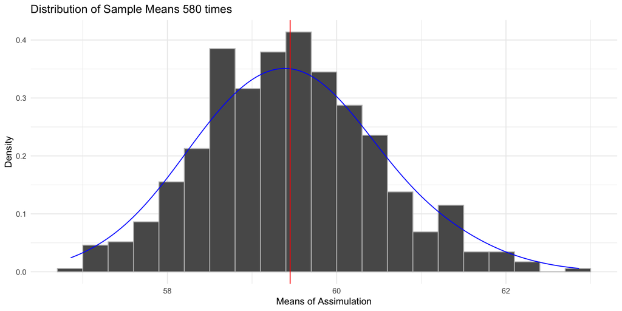

## Interpret

Formula-based standard error is 1.0230.

Simulation standard deviation is 1.0223, which is very close to formula-based standard error.

## Binary Variable

Suppose we have a partial population of 10000, among which 8000 are older or equal to 18 years old and the rest 2000 are minors. We assign older with 1, and minors with 0.

Then we create a Bernoulli distribution with p = 0.8.

Mean = 0.8

For variable,“Adults or Minors”, Var[X] = p(1-p)= 0.8*0.2 = 0.16

SD[X] = $\sqrt{p(1-p)}$ = $\sqrt{0.16}$ = 0.4

SE = $\frac{SD}{\sqrt{n}}$ = 0.4/100 = 0.004

## Confidence Interval

89% confidence interval = mean +/- 1.598SE = 0.8 +/- 0.006 = (0.794, 0.806)

The probability of the true proportion of adults in the population to be within range 0.794 to 0.806 is 0.89.

95% confidence interval = mean +/- 1.98SE = 0.8 +/- 0.008 = (0.792, 0.808)

The probability of the true proportion of adults in the population to be within range 0.792 to 0.808 is 0.95.

99% confidence interval = mean +/- 2.58SE = 0.8 +/- 0.010 = (0.790, 0.810)

The probability of the true proportion of adults in the population to be within range 0.790 to 0.810 is 0.99.

## Binary Variable Simulation

First we randomly select 500 people from the population and count p for this sample.

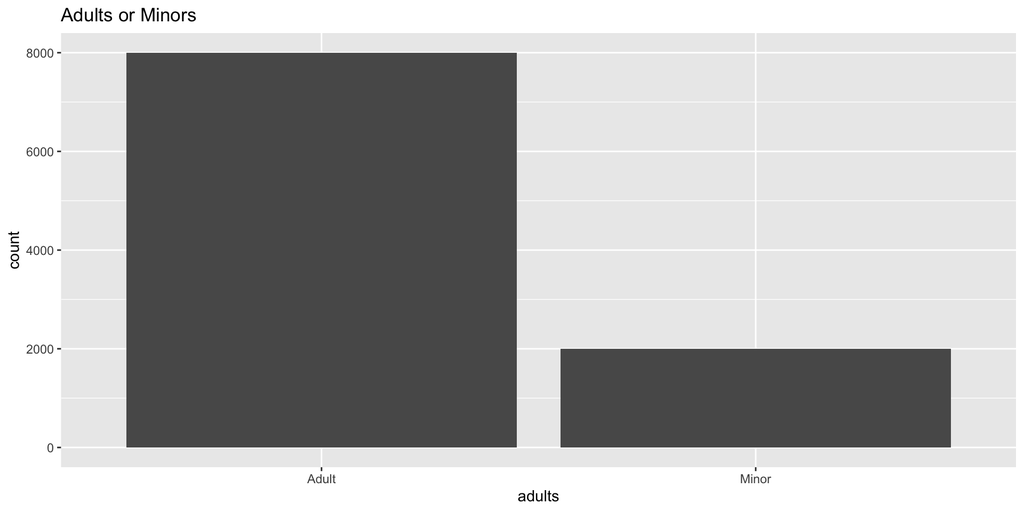

## 500 units

p of 500 units is 0.8.

Standard deviation is 0.4.

Standard error is 0.01789.

## Simulation 20 times

Now we draw 20 samples with 500 units each.

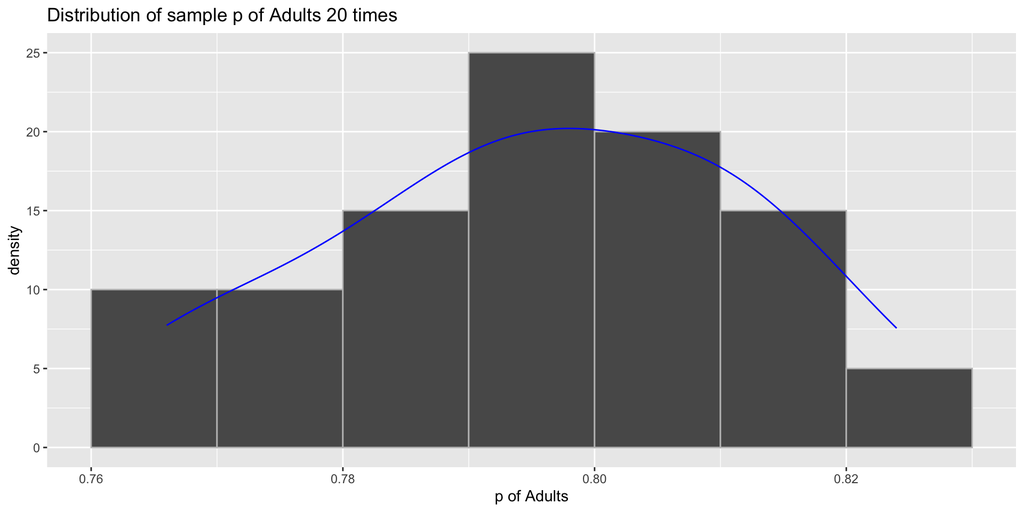

## Simulation 200 times

Now we draw 200 samples with 500 units each.

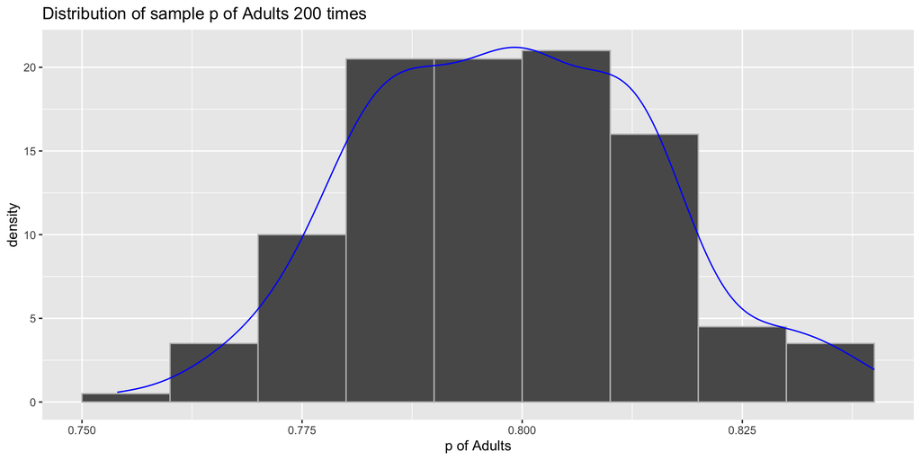

## Simulation 2000 times

Now we draw 2000 samples with 500 units each.

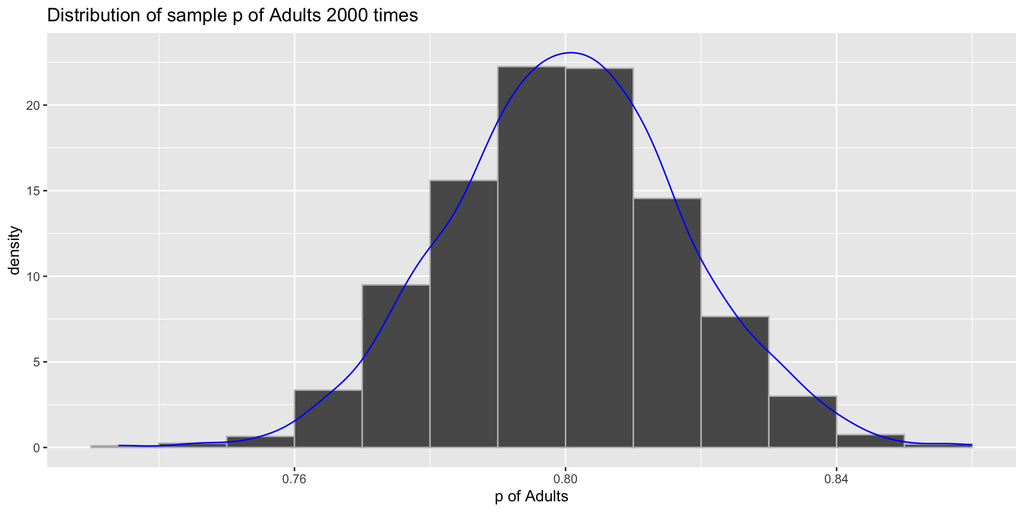

## Intepret

Formula-based error is 0.01789.

Standard deviation of simulation mean (200 times) is 0.01560.

Standard deviation of simulation mean (2000 times) is 0.01742.

The larger the simulation sample, the closer the standard deviation of simulation mean to formula-based standard error.